# 第 6 章 树模型

分类树和回归树是简单而强大的递归划分算法，因 Breiman 等人（1984）的专著而得到广泛应用。处理表格数据时，决策树及其扩展通常是高效的预测工具。许多机器学习竞赛的获胜方案，尤其是 Kaggle 网站$^{13}$上的方案，都采用了树模型的改进版本。例如，Olson 等人（2018）针对生物信息学问题比较了 13 种算法；若不计神经网络，提升树和随机森林分列前两位。

近年来，机器学习在金融领域迅速普及，越来越多的研究开始把树模型用于投资组合配置。相关文献很多，包括 Ballings 等人（2015）、Patel、Shah、Thakkar 和 Kotecha（2015a）、Patel、Shah、Thakkar 和 Kotecha（2015b）、Moritz 和 Zimmermann（2016）、Krauss、Do 和 Huck（2017）、Gu、Kelly 和 Xiu（2020b）、Guida 和 Coqueret（2018a）、Coqueret 和 Guida（2020），以及 Simonian 等人（2019），此处仍未穷尽。Bryzgalova、Pelger 和 Zhu（2019）的一项突出贡献，是利用简单树对股票排序并据此构造因子；他们将这种方法称为“资产定价树”。

在本章中，我们回顾与树相关的方法及其在投资组合选择中的应用。

## 6.1 简单树

### 6.1.1 原理

决策树试图把数据集划分为若干**内部同质的节点**。给定目标变量 $\mathbf{Y}$ 和特征 $\mathbf{X}$，树会反复将样本分组（通常每次二分），使各节点内部的 $\mathbf{Y}$ 尽可能相似。每次分裂都依据某一项特征完成。术语上，当 $\mathbf{Y}$ 为实数时，模型称为回归树；当 $\mathbf{Y}$ 为类别时，则称为*分类树*。

在正式定义这一方法之前，先用图 6.1 直观说明其过程。图中共有 12 颗星，每颗星有三个特征：颜色、大小和复杂度（分支数）。

[figure not shown]

图 6.1：基本树结构与分裂过程示意图。

目标变量是颜色；为便于处理，可以把颜色表示成相应的波长。第一次分裂可以依据大小，也可以依据复杂度。显然，复杂度更合适：复杂的星星是蓝色或绿色，简单的星星则是黄色、橙色或红色。若按大小分裂，小星星一组会混入蓝色和黄色，大星星一组则会混入绿色和橙色。

第二步再把两个子节点各分裂一次。此时只剩大小这项特征有区分作用，因此分裂很直接。最终，这棵示意树得到四个内部较为一致的叶节点。它与因子投资的类比也很清楚：颜色对应资产表现，例如红色表示表现较好，蓝色表示表现平平；星星的大小和复杂度则换成公司规模、会计比率等公司特征。因此，我们希望找到能够区分未来表现较好与较差公司的特征。

下面转向回归树的正式构造，即节点分裂过程。这里沿用 Breiman 等人（1984）以及 Hastie、Tibshirani 和 Friedman（2009）第 9 章的标准方法。给定包含 $I$ 个观测的样本 ($y_i$,$\mathbf{x}_i$)，回归树寻找一个分裂点，使两个子节点内部 $y_i$ 的总离差最小；两个子节点的大小不必相同。具体分两步进行：先为每项特征 $x_i^{(k)}$ 找到使 $\mathbf{Y}$ 在子节点内尽可能同质的最佳分裂点，再从所有特征中选出同质性最高的一项。

回归树中的同质性与方差密切相关。我们希望同一节点内的 $y_i$ 尽可能接近，因此要分别最小化两个节点内的**变异程度**（或**离散度**），再将二者相加。直接把两个方差相加会忽略节点大小，所以这里采用总离差，也就是方差乘以该节点的样本数。

下面的记号稍显繁复，因为上标 **k** 表示特征索引；理解思路时可以暂时忽略它。第一步是分别找出每项特征的最佳分裂点，即求解 $\underset{c^{(k)}}{\text{argmin}} \ V^{(k)}_I(c^{(k)})$。

\begin{equation} \tag{6.1} V^{(k)}_I(c^{(k}))= \underbrace{\sum_{x_i^{(k)}<c^{(k)}}\left(y_i-m_I^{k,-}(c^{(k)}) \right)^2}_{\text{Total dispersion of first cluster}} + \underbrace{\sum_{x_i^{(k)}>c^{(k)}}\left(y_i-m_I^{k,+}(c^{(k)}) \right)^2}_{\text{Total dispersion of second cluster}}, \end{equation}

其中

\begin{align*} m_I^{k,-}(c^{(k)})&=\frac{1}{\#\{i,x_i^{(k)}<c^{(k)} \}}\sum_{\{x_i^{(k)}<c^{(k)} \}}y_i \quad \text{ and } \\ m_I^{k,+}(c^{(k)})&=\frac{1}{\#\{i,x_i^{(k)}>c^{(k)} \}}\sum_{\{x_i^{(k)}>c^{(k)} \}}y_i \end{align*}

它们分别表示 $Y$ 在 $X^{(k)}$ 小于或大于 $c$ 条件下的节点内均值。符号 $\#\{\cdot\}$ 表示集合中的样本数。对于特征 $k$，最佳分裂点 $c^{k,*}$ 就是使两个子节点总离差最小的分裂点。

最佳分裂点满足 $c^{k,*}= \underset{c^{(k)}}{\text{argmin}} \ V^{(k)}_I(c^{(k)})$。比较所有候选特征后，树会选择能在全部特征及其分裂点中使总离差最小的那一项：

$$k^*=\underset{k}{\text{argmin}} \ V^{(k)}_I(c^{k,*})$$

完成一次分裂后，同样的过程会在两个新形成的子节点中继续。可以用多种准则决定何时停止（见第 6.1.3 节）。最简单的做法是限制树的最大层数，即最大深度。另一种常见做法是要求每次分裂至少带来一定的改善：若分裂带来的总离差下降低于给定阈值，就不再继续。关于决策树的更多技术细节，可参见 Hastie、Tibshirani 和 Friedman（2009）第 9.2.4 节。

树构建（训练）完成后，对新样本的预测很直接：根据该样本的特征值沿树向下移动，最终落入某个叶节点；该叶节点内标签的均值就是预测值。当然，这只适用于数值标签。分类任务中的处理方式将在下文说明。

### 6.1.2 分类问题的进一步说明

分类任务比回归任务稍复杂，最明显的区别在于如何衡量离散度或异质性。损失函数必须考虑到，最终输出不是单个数值，而是一个向量。输出 $\tilde{\textbf{y}}_i$ 的元素个数等于类别数，每个元素表示样本属于相应类别的概率。

例如，若有*买入、持有和卖出* 3 个类别，每个样本的标签就包含 3 个分量。按照这一顺序，买入类别的标签可写为 (1,0,0)。相关概念可参见第 4.5.2 节。

在树中，标签会在每个节点内汇总。典型输出如 (0.6,0.1,0.3)，表示该节点中 60% 的样本属于买入类、10% 属于持有类、30% 属于卖出类。

损失函数需要体现标签的多维性。构建树的目标是提高节点同质性，因此损失应惩罚类别比例过于分散的情况。例如，输出 (0.3,0.4,0.3) 比 (0.8,0.1,0.1) 更难明确归类。

因此，算法追求的是纯度：它寻找能产生尽可能纯的子节点的分裂准则，也就是让某个类别占据明显优势，或至少把类别集中到少数几类。文献提出了多种度量，它们都基于各类别在节点中的比例。若共有 $J$ 个类别，以 $p_j$ 表示相应类别的比例，则每个叶节点常用的损失函数包括：

- 基尼不纯度指数：$ 1-\sum_{j=1}^Jp_j^2; $
- 误分类率：$ 1-\underset{j}{\text{max}}\, p_j; $
- 熵：$ -\sum_{j=1}^J\log(p_j)p_j. $

基尼不纯度等于 1 减去赫芬达尔指数；后者常用于衡量投资组合的集中度。因此，树会寻找类别最集中的划分。  
当某个 $ p_j=1 $、其余比例均为零时，基尼不纯度取得最小值 0；其最大值为 $ 1-1/J$，并在所有 $ p_j=1/J $ 时取得。另外两种损失也具有类似性质。误分类率的缺点是不可微，这也是实践中更常使用另外两种度量的原因之一。

树生长完成后，新样本会沿树落入某个叶节点。该叶节点对应一组类别比例；做出分类预测时，通常选择比例（或概率）最高的类别。

### 6.1.3 剪枝准则

构建树时，可以持续分裂，直到得到一棵完全生长的树，也就是：

- 所有样本都各自落入单独的叶节点；和/或
- 每个叶节点中的样本都无法再依据现有特征进一步区分。

达到这一状态后，树就无法继续分裂。

显然，当预测变量有效、数量较多且为数值型时，完全生长的树往往能在训练样本上达到近乎完美的拟合。然而，训练样本中的细枝末节对样本外预测通常没有多少价值。例如，完美拟合 2000 至 2006 年的数据规律，并不意味着这些规律在 2007 至 2009 年仍然有用。树中最可靠的部分通常靠近根节点，因为这些节点覆盖了大量数据；上层节点的均值由许多样本计算而来，因而更可信。最初几次分裂揭示的是较普遍的规律，而最深层的分裂往往只是在迎合训练样本的特殊性。

因此，必须限制树的规模。树的剪枝方法很多，分别依赖不同的停止准则，常见做法包括：

- 规定每个终端节点（叶节点）的最小样本数。这样可以确保每个叶节点包含足够多的样本，使其标签均值更可靠。
- 类似地，只有当当前节点达到一定样本数时，才允许继续分裂。该准则与上一项密切相关。
- 要求拟合至少改善到某个阈值。如果一次分裂不能充分降低损失，就没有必要执行。用户给定一个较小的 $ \epsilon>0 $；只有当分裂后的损失小于分裂前损失的 $ 1-\epsilon $ 倍时，才接受该分裂。
- 限制树的深度。深度是从根节点到任一叶节点所经历的最大分裂次数。

下面的示例会同时采用上述所有准则，但实践中通常使用其中一到两个即可。

### 6.1.4 代码与解读

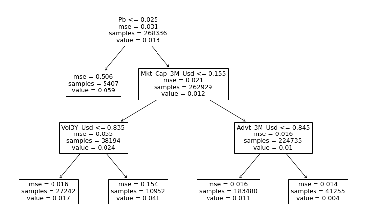

```python
from sklearn import tree # Tree module
import matplotlib.pyplot as plt # to adjust tree plot

X = data_ml.iloc[:,3:96] # recall features/predictors, full sample
y = data_ml['R1M_Usd'] # recall label/Dependent variable, full sample

fit_tree = tree.DecisionTreeRegressor( # Definining the model
  min_samples_split = 8000, # Min nb of obs required to continue splitting
  max_depth = 3, # Maximum depth (i.e. tree levels)
  ccp_alpha=0.000001, # complexity parameters
  min_samples_leaf =3500 # Min nb of obs required in each terminal node (leaf)
        )
fit_tree.fit(X, y) # Fitting the model
fig, ax = plt.subplots(figsize=(13, 8)) # resizing
tree.plot_tree(fit_tree,feature_names=X.columns.values, ax=ax) # Plot the tree
plt.show()
```

图 6.2：基于公司特征的简单树。因变量为未来 1 个月收益率。

因此，构建树时需要施加限制。代码中的 min_samples_leaf=3500 要求每个叶节点至少包含 3500 个样本；min_samples_split=8000 要求一个节点至少包含 8000 个样本，才允许继续分裂。这些参数自然应随训练样本规模调整。ccp_alpha=0.000001 控制最小代价复杂度剪枝的强度，取值越大，剪枝越强。最后，max_depth=3 表示从根节点到任一终端叶节点最多经历三次分裂。

若以终端叶节点数衡量树的复杂度，那么复杂度通常会随 min_samples_leaf、min_samples_split 和 ccp_alpha 增大而降低，随 max_depth 增大而提高。

模型训练完成（即树生长完成）后，对任一样本的预测值，就是该样本最终所在叶节点的标签均值。

```python
y_pred=fit_tree.predict(X.iloc[0:6,:])   # Test (prediction) on the first six instances of the sample
```

```python
print(f'y_pred: {y_pred}')
```

```
y_pred: [0.01088066 0.01088066 0.01088066 0.01088066 0.01088066 0.01088066]
```

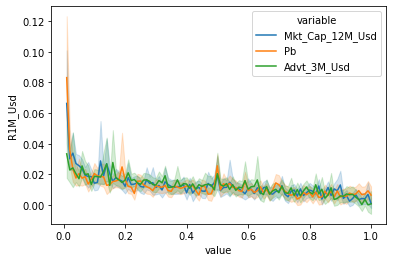

```python
import seaborn as sns
unpivoted_data_ml = pd.melt(data_ml[['R1M_Usd','Mkt_Cap_12M_Usd','Pb','Advt_3M_Usd']], id_vars='R1M_Usd') # selecting and putting in vector
sns.lineplot(data = unpivoted_data_ml, y='R1M_Usd', x='value', hue='variable'); # Plot from seaborn
```

图 6.3：以市值、市净率和成交量得分为条件的未来 1 个月平均收益率。

最后，我们评估一棵在训练集上生长的树在测试集上的预测质量。这里使用一棵更深的树，最大深度为五。

```python
y_train = training_sample['R1M_Usd'].values # recall features/predictors, full sample
X_train = training_sample[features].values # recall label/Dependent variable, full sample

fit_tree2 = tree.DecisionTreeRegressor( # Definining the model
  min_samples_split = 4000, # Min nb of obs required to continue splitting
  max_depth = 5, # Maximum depth (i.e. tree levels)
  ccp_alpha=0.0001, # complexity parameters
  min_samples_leaf =1500 # Min nb of obs required in each terminal node (leaf)
        )
fit_tree2 = fit_tree2.fit(X_train, y_train) # Fitting the model

mse = np.mean((fit_tree2.predict(X_test) - y_test)**2)
print(f'MSE: {mse}')
```

```
MSE: 0.03699695809185004
```

将平均结果转换为命中率。

```python
hitratio = np.mean(fit_tree2.predict(X_test) * y_test > 0)
print(f'Hit Ratio: {hitratio}')
```

```
Hit Ratio: 0.5460346399270738
```

均方误差通常不易直观解释，因为很难把收益率预测误差直接对应到投资决策的后果。命中率更直观，它衡量方向判断正确、因而可能盈利的投资所占比例。当然，这一指标也不完美：55% 的小额盈利可能被 45% 的大额亏损抵消。尽管如此，命中率仍是常用指标，也对应二元分类任务中的准确率。这里 0.546 的准确率尚可。虽然任何高于 50% 的数值看起来都有价值，但交易成本会侵蚀收益，因此实践中的最低参考阈值可能至少要达到 52%。

## 6.2 随机森林

单棵树能够直观展示 $\mathbf{Y}$ 与 $\mathbf{X}$ 的关系，但还可以通过集成多个预测模型来改进其表现。第 11 章将从更一般的角度详细讨论这种**模型聚合**思路。

### 6.2.1 原理

面对多种建模方案时，通常无法事先知道哪个单一模型最好。因此，只要各模型的误差相关性不太高，把它们组合起来就是分散预测误差的合理办法。Schapire（1990）为模型多样化奠定了部分理论基础。

随后，Ho（1995）从实践角度进一步发展了这一思路，而 Breiman（2001）则成为随机森林领域的主要参考文献。Yin（2020）成功地使用 Bagging（自助聚合）聚合股票收益预测。可以通过两种方式从简单树生成多个预测模型，随机森林把二者结合起来：

- 第一，在彼此相似但不完全相同的数据集上训练模型。一种实现方法是重采样：经典 Bootstrap（自助抽样）采用有放回抽样，某些实现也允许无放回抽样，从而在每次建树时得到新的训练数据。
- 第二，减少每次建模使用的预测变量。不同模型使用不同的特征子集；用户指定保留多少项特征，算法则在每次建树时随机抽取相应数量的特征。

这样就可以方便地生长许多不同的树，而集成模型只是所有树的**加权组合**。通常采用等权重，这是一种不依赖先验判断且较稳健的选择。图 6.4 展示了这种简单组合，也就是 Bagging。最终预测值就是各棵树预测值的平均数。

[figure not shown]

图 6.4：随机森林对多棵树的输出进行组合。

随机森林建立在 Bagging 思想之上，通常比单棵树更有效。Ballings 等人（2015）、Patel、Shah、Thakkar 和 Kotecha（2015a）、Krauss、Do 和 Huck（2017）以及 Huck（2019）都使用了随机森林，并取得良好表现。Breiman（2001）首先针对分类树推导了随机森林的理论性质。在分类任务中，模型通过投票作出决策：每棵树投票支持一个类别，得票最多的类别胜出；若票数相同，可以随机决定。Breiman（2001）将间隔函数定义为

$mg=M^{-1}\sum_{m=1}^M1_{\{h_m(\textbf{x})=y\}}-\max_{j\neq y}\left(M^{-1}\sum_{m=1}^M1_{\{h_m(\textbf{x})=j\}}\right),$

左侧是 $ M $ 棵树 $ h_m $ 投给正确类别的平均票数，  
即基于 $x$ 的模型 $h_m$ 与真实标签 $y$ 一致的比例；右侧则是其他任一类别所得平均票数的最大值。间隔反映了集成森林正确分类的置信程度。泛化误差定义为  
$mg$ 严格小于零的概率。Breiman（2001）表明，以泛化误差衡量的集成分类误差上界为 $ \bar{\rho}(1-s^2)/s^2$，其中

- $s$ 是单个分类器的强度（平均质量），
- $ρ$ 是学习器之间的平均相关性。

值得注意的是，Breiman（2001）还证明，当树的数量趋于无穷时，误差会收敛到一个有限值。这解释了随机森林为何不容易因增加树的数量而过拟合。

Breiman（2001）的原始论文研究的是分类模型，此后许多文章也讨论了回归森林。感兴趣的读者可参见 Biau（2012）和 Scornet 等人（2015）。有关集成分类的进一步结果，可参见 Biau、Devroye 和 Lugosi（2008）；Denil、Matheson 和 De Freitas（2014）的简短综述则概括了该领域当时的主要进展。

### 6.2.2 代码与结果

随机森林有多种实现。为简单起见，这里采用 scikit-learn 软件包中的实现，当然也有其他选择。 randomForest 的语法与许多机器学习软件包类似，不同实现提供的参数选项可能非常丰富。下面训练一个模型，并展示测试集中前 5 个样本的预测值。

```python
from sklearn.ensemble import RandomForestRegressor

fit_RF = RandomForestRegressor(n_estimators = 40, # Nb of random trees
criterion ='mse', # function to measure the quality of a split
min_samples_split= 250, # Minimum size of terminal cluster
bootstrap=False, # replacement
max_features=30, # Nb of predictive variables for each tree
max_samples=10000 # Size of (random) sample for each tree
)
fit_RF.fit(X_train, y_train) # Fitting the model
fit_RF.predict(pd.DataFrame(X_test).iloc[0:5,]) # Prediction over the first 5 test instances
```

```
array([ 0.00139083,  0.02137373,  0.04259802, -0.01310026,  0.00028897])
```

在上例中，每个学习器（树）使用随机抽取的 10,000 个样本训练，抽样不放回；参数 min_samples_split=250 要求节点至少包含 250 个样本才允许继续分裂。模型共聚合 40 棵树，每棵树都从全部特征中随机选择 30 个预测变量。

与单棵树不同，随机森林的学习结果很难用一张图完整说明。虽然可以逐一提取 40 棵树，但几乎无法进行综合可视化。第 13.1.2 节介绍的特征重要性可以提供一种简化视角。

最后评估模型的预测表现。

```python
from sklearn.metrics import mean_squared_error
mse=mean_squared_error(y_test, fit_RF.predict(X_test))
print(f'MSE: {mse}')
```

```
MSE: 0.03686227217696956
```

```python
hitratio = np.mean(fit_RF.predict(X_test) * y_test > 0)
print(f'Hit Ratio: {hitratio}')
```

```
Hit Ratio: 0.5320476298997265
```

MSE 低于 4%，命中率超过 53%，高于 50% 和 52% 这两个参考阈值。

下面检验改用分类任务能否提高命中率。首先使用新的模型设定进行训练，标签为 R1M_Usd_C。

```python
from sklearn.ensemble import RandomForestClassifier

fit_RF_C = RandomForestClassifier(
n_estimators = 40, # Nb of random trees
criterion ='gini', # function to measure the quality of a split
min_samples_split= 250, # Minimum size of terminal cluster
bootstrap=False, # replacement
max_features=30, # Nb of predictive variables for each tree
max_samples=20000 # Size of (random) sample for each tree
)
fit_RF_C=fit_RF_C.fit(X_train, y_c_train) # Fitting the model
```

接着计算二元方向预测正确的比例。

```python
hitratio = np.mean(fit_RF_C.predict(X_test) == y_c_test)
print(f'Hit Ratio: {hitratio}')
```

```
Hit Ratio: 0.5030480856882407
```

准确率并不理想。除训练集与测试集可能具有不同规律外，还有两种可能解释。第一，训练样本或许太小。原始训练集包含 200,000 多个样本，而上述设定只保留了其中十分之一，因而可能遗漏了有用信息。第二，每棵树使用的预测变量数设为 30，约占全部可用预测变量的三分之一，这给算法留下了抽到较弱预测变量的可能。分类任务和回归任务中，程序默认选取的预测变量数分别为 $\sqrt{p}$ 和 $p/3$，其中 $p$ 为特征总数。

## 6.3 提升树：AdaBoost

与不区分模型优劣的简单聚合相比，提升法更进一步。随机森林依靠许多树之间的差异来改善整体表现；提升法则按顺序加入新树，并要求每棵新树都在已有模型基础上继续改进。提升方法很多，这里介绍两种容易用树实现的算法。第一种是 AdaBoost，即自适应提升，它逐步把注意力转向当前预测误差最大的样本。第二种是 XGBoost，它更为灵活，每棵新树都以降低训练样本损失为目标。

### 6.3.1 方法论

AdaBoost 起源于 Freund 和 Schapire（1996、1997）的工作；关于提升法的系统论述，还可参见 Schapire 和 Freund（2012）的专著。Friedman 等人（2000）提出了扩展版本 Real AdaBoost，Drucker（1997）则把该方法推广到回归任务。Breiman 等人（2004）进一步给出了理论分析。

先给出算法的总体结构：

- 将样本权重初始化为相等值 $ w_i=I^{-1} $；
- 对 $ m=1,\dots,M $ 重复以下步骤：
1. 寻找使加权损失 $\sum_{i=1}^Iw_iL(l_m(\textbf{x}_i),\textbf{y}_i)$ 最小的学习器 $l_m$；
1. 计算该学习器的权重；

\begin{equation} \tag{6.2} a_m=f_a(\textbf{w},l_m(\textbf{x}),\textbf{y}); \end{equation}

1. 更新各样本的权重；

\begin{equation} \tag{6.3} w_i \leftarrow w_ie^{f_w(l_m(\textbf{x}_i), \textbf{y}_i)}; \end{equation}

1. 对 $w_i$ 归一化，使其总和为 1；
- 样本 $x_i$ 的输出，是 $\sum_{m=1}^M a_ml_m(\textbf{x}_i)$ 的一个简单函数：

\begin{equation} \tag{6.4} \tilde{y}_i=f_y\left(\sum_{m=1}^M a_ml_m(\textbf{x}_i) \right). \end{equation}

下面逐步解释该算法。这套一般形式适用于 AdaBoost 的许多变体，随后会具体说明函数 $fa$ 和 $fw$。

1. 第一步寻找使加权损失最小的学习器（树）$l_m$。基础损失函数 $L$ 取决于具体任务，即回归或分类。
2. 第二步和第三步构成 AdaBoost 的核心，它们规定算法如何按顺序自适应。模型最终要聚合多个学习器，因此比起给所有学习器相同权重，更合理的做法是分别确定权重。函数 $fa$ 应满足一个自然要求：误差越小、越准确的学习器，权重越大。
3. 第三步调整样本权重。函数 $fw$ 会提高当前模型预测较差、误差较大样本的权重，使下一位学习器更关注这些难以预测的样本。
4. 随后只是一个归一化步骤。 表 6.1 列出了文献中两组具体的权重函数。原始 AdaBoost（Freund 和 Schapire（1996、1997））使用二元标签，取值仅为 +1 和 -1。第二个例子来自 Drucker（1997），专门处理实值标签的回归任务。其他形式可参见 Schapire（2003）和 Ridgeway、Madigan 与 Richardson（1999）。

[output not shown]

表 6.1：AdaBoost 类算法中的函数示例。

样本权重的更新遵循类似逻辑。新权重与 $w_i\left(\frac{1-\epsilon}{\epsilon} \right)^{\epsilon_i}$ 成正比。若预测正确，即 $\epsilon_i=0$，权重不变；若预测错误，即 $\epsilon_i=1$，权重会根据整体误差 $\epsilon$ 调整。当学习器有效且误差较小 ($\epsilon<1/2$) 时，$(1-\epsilon)/\epsilon>1$，该样本的权重就会上升。因此，下一轮学习器会更加关注样本 $i$。

因此，权重较大的样本 $wi$ 会对所在节点的总离差产生更大影响。分类任务的调整更复杂；Ting（2002）给出了样本加权树的生长算法。这一思路与利用损失矩阵调整误分类风险密切相关，参见 Hastie、Tibshirani 和 Friedman（2009）第 9.2.4 节。

第二种方式是随机抽样。若样本权重为 $w_i$，可以按由 $w_i$ 决定的概率分布抽取训练样本，再训练学习器。这样，权重较大的样本更有可能进入训练集。原始 AdaBoost 算法采用的正是这种方法。

### 6.3.2 示例

```python
from sklearn.tree import DecisionTreeClassifier
from sklearn.ensemble import AdaBoostClassifier

fit_adaboost_C = AdaBoostClassifier(DecisionTreeClassifier(
        max_depth=3), # depth of the tree
        n_estimators=3) # Number of trees
fit_adaboost_C.fit(X_train, y_c_train) # Fitting the model
```

```
AdaBoostClassifier(base_estimator=DecisionTreeClassifier(max_depth=3),
                   n_estimators=3)
```

最后评估分类器的表现。

```python
from sklearn.metrics import accuracy_score # introducing buit-in function for accuracy
hitratio=accuracy_score(y_c_test, fit_adaboost_C.predict(X_test)) # Hitratio
print(f'Hit Ratio: {hitratio}')
```

```
Hit Ratio: 0.49641066545123064
```

### 6.4 提升树：极端梯度提升

树提升的思想由 Mason 等人（2000）、Friedman（2001）和 Friedman（2002）等工作推广。与随机森林对学习器进行简单聚合不同，提升法会在学习器层面进行自适应调整或优化。在每一步 $s$，组合模型 $M_S=\sum_{s=1}^{S-1}m_s+m_S$ 中最后加入的学习器 $m_S$，都专门用于降低 $M_S$ 在训练样本上的损失。

下面紧密依照 T. Chen 和 Guestrin（2016）的原始工作展开。他们的算法预测准确、可定制性强，本书的实证部分也采用其实现。另一种常用方案是 LightGBM，参见 Ke 等人（2017）。XGBoost 要最小化的目标函数为

$O=\underbrace{\sum_{i=1}^I \text{loss}(y_i,\tilde{y}_i)}_{\text{error term}} \quad + \underbrace{\sum_{j=1}^J\Omega(T_j)}_{\text{regularisation term}}.$

第一项对所有样本求和，衡量真实标签与模型输出之间的差异；第二项对所有树求和，用于惩罚过于复杂的模型。

为简化推导，下面采用最基本的平方损失 $\text{loss}(y,\tilde{y})=(y-\tilde{y})^2$，于是： $O=\sum_{i=1}^I \left(y_i-m_{J-1}(\mathbf{x}_i)-T_J(\mathbf{x}_i)\right)^2+ \sum_{j=1}^J\Omega(T_j).$

### 6.4.1 损失项的处理

假设已经构建了 $j=1,\dots,J-1$ 的所有树 $T_j$，因而也得到了模型 $M_{J-1}$。接下来应如何最优地选择树 $T_J$？将目标函数改写为 \begin{align*} O&=\sum_{i=1}^I \left(y_i-m_{J-1}(\mathbf{x}_i)-T_J(\mathbf{x}_i)\right)^2+ \sum_{j=1}^J\Omega(T_j) \\ &=\sum_{i=1}^I\left\{y_i^2+m_{J-1}(\mathbf{x}_i)^2+T_J(\mathbf{x}_i)^2 \right\} + \sum_{j=1}^{J-1}\Omega(T_j)+\Omega(T_J) \quad \text{(squared terms + penalisation)}\\ & \quad -2 \sum_{i=1}^I\left\{y_im_{J-1}(\mathbf{x}_i)+y_iT_J(\mathbf{x}_i)-m_{J-1}(\mathbf{x}_i) T_J(\mathbf{x}_i))\right\}\quad \text{(cross terms)} \\ &= \sum_{i=1}^I\left\{-2 y_iT_J(\mathbf{x}_i)+2m_{J-1}(\mathbf{x}_i) T_J(\mathbf{x}_i))+T_J(\mathbf{x}_i)^2 \right\} +\Omega(T_J) + c \end{align*} 在第 $J$ 步，所有已知项，即由 $J-1$ 索引的项，都不影响当前优化，因此可统一吸收到常数 $c$ 中。

平方损失下的推导较为直接。对于更复杂的损失函数，则需要使用泰勒展开，详见原始论文。

### 6.4.2 复杂度惩罚

继续推导前，需要明确惩罚项的形式。对于给定的树 $T$，用 $T(x)=w_{q(x)}$ 表示其结构，其中 $w$ 是某个叶节点的输出值，$q(\cdot)$ 是把输入映射到最终叶节点的函数。图 6.5 展示了这种编码方式：函数 $q$ 决定样本经过的路径，向量 $\textbf{w}=w_i$ 则记录终端叶节点的取值。

[figure not shown]

图 6.5：决策树的编码方式：树结构、节点与叶节点取值的分解。

用 $l=1,\dots,L$ 表示树的叶节点索引。XGBoost 将复杂度定义为： $\Omega(T)=\gamma L+\frac{\lambda}{2}\sum_{l=1}^Lw_l^2,$ 其中

- 第一项惩罚**叶节点总数**；
- 第二项惩罚**输出值的大小**，这有助于降低方差。

第一个惩罚项抑制叶节点数量，因而限制树的复杂度；第二个惩罚项则收缩最新一棵树带来的调整幅度。

### 6.4.4 树结构

不过，迭代生长新树的过程仍与简单树相似。算法需要逐项测试特征，找出能使每次分裂后的目标函数最小的特征。接下来要确定最佳深度以及何时停止生长。具体做法是：

- 逐个节点考察；
- 对每个节点，根据目标函数判断该分裂是否有益：$\text{Gain}=\frac{1}{2}\left(\text{Gain}_L+\text{Gain}_R-\text{Gain}_O \right)-\gamma$；
- 每项增益都根据相应节点中的样本计算：$\text{Gain}_\mathcal{X}= \frac{\left(\sum_{i\in I_\mathcal{X}}(y_i -m_{J-1}(\mathbf{x}_i))\right)^2}{\left(1+\frac{\lambda}{2}\right)\#\{i\in I_\mathcal{X}\}},$ 其中 $I_\mathcal{X}$ 是节点 $\mathcal{X}$ 的样本集合。

$\text{Gain}_O$ 是分裂前原节点的增益，$\text{Gain}_L$ 和 $\text{Gain}_R$ 分别是左、右子节点的增益。上式还包含 $-\gamma$ 这一调整：一次分裂用两个新叶节点替代一个旧叶节点，叶节点净增加 1 个，因此 $\Delta L =1$，相应的复杂度惩罚为 $\gamma$。

最后，XGBoost 还使用**学习率**。每棵新树都按因子 $\eta$ 缩放，其中 $\eta \in (0,1]$；加入新树 $T_J$ 时，其输出值要乘以 $\eta$。这种收缩非常重要，因为直接叠加 100 棵已优化的树很容易对训练样本过拟合。

### 6.4.5 扩展

还可以使用若干附加功能，进一步防止提升树过拟合。树的数量足够多时，集成模型可以很好地拟合训练样本，却未必能在样本外保持良好表现。

在 Srivastava 等人（2014）开创性工作的基础上，Rashmi 和 Gilad-Bachrach（2015）提出了 DART (Dropout for Additive Regression Trees) 模型。其思路是在训练期间随机舍弃一定数量的树。完整设定见 https://xgboost.readthedocs.io/en/latest/tutorials/dart.html。

单调约束是 xgboost 和 lightgbm 都支持的另一项功能。有时，我们有理由预期某项特征会对标签产生单调影响。例如，若相信动量效应，那么在股票横截面上，过去收益率越高，未来收益率也应越高。

由于分裂算法具有递归结构，可以根据单调要求决定某项特征上的分裂是否可接受。图 6.6 展示了这一过程，其中所有分裂都基于同一项特征。第一次分裂较简单，只需检查两个子节点的均值是否按预期方向排序。更深层的分裂则更复杂：上层分裂确定的均值会为下层叶节点的可接受均值设定边界。若某次分裂违反这些边界，就忽略该分裂，改用其他变量。

[figure not shown]

图 6.6：施加单调约束。底部叶节点中的粗体蓝字表示约束范围。

### 6.4.6 代码与结果

本节使用 XGBoost 软件包训练模型。其他选择包括 catboost、gbm、lightgbm，以及 h2o 自带的提升模型实现。与许多软件包不同，XGBoost 函数要求使用特定语法和专用数据格式，因此第一步是按要求封装数据。

```python
import xgboost as xgb # The package for boosted trees

data_ml['R1M_Usd_quantile'] = data_ml.groupby('date')['R1M_Usd'].transform(         # creating quantile...
        lambda x: pd.qcut(x, 100, labels=False, duplicates=('drop'), precision=50)) # ...for selecting extreme values

boolean_quantile=(data_ml.loc[separation_mask]['R1M_Usd_quantile'].        # boolean array for selecting rows
                  values<=0.2) | (data_ml.loc[separation_mask]['R1M_Usd_quantile'].values>=0.8) # selecting extreme values

###############################################################################
train_features_xgb=training_sample.loc[boolean_quantile,features_short] # Independent variables
train_label_xgb=training_sample.loc[boolean_quantile,'R1M_Usd'] # Dependent variable
train_matrix_xgb=xgb.DMatrix(train_features_xgb, label=train_label_xgb) # XGB format!
```

第二步是可选的：确定要施加哪些单调约束。为简单起见，这里只设置三项约束：

1. 市值为负向约束，因为规模异象意味着大公司的收益率较低；
2. 市净率为负向约束，因为价值异象意味着估值较高的公司收益率较低；
3. 过去一年收益率为正向约束，因为动量异象意味着赢家继续跑赢输家。

```python
mono_const="(0, 0, -1, 1, 0, -1, 0)" # Initialize the vector -- "-1" == decreasing, "+1" increasing
# Decreasing in market cap -- mono_const[2]
# Increasing in past return -- mono_const[3]
# Decreasing in price-to-book -- mono_const[5]
```

第三步是在格式化后的训练数据上拟合模型。这里同时启用单调约束和 DART 功能，后者通过 rate_drop 设置。与随机森林类似，提升树也可以在数据子集上生长单棵树：行方向随机抽取部分样本，列方向只保留部分预测变量。下面分别通过参数 subsample 和 colsample_bytree 实现。

```python
params={'eta' : 0.3,                          # Learning rate
  'objective' : "reg:squarederror",     # Objective function
  'max_depth' : 4,                      # Maximum depth of trees
  'subsample' : 0.6,                    # Train on random 60% of sample
  'colsample_bytree' : 0.7,             # Train on random 70% of predictors
  'lambda' : 1,                         # Penalisation of leaf values
  'gamma' : 0.1,                        # Penalisation of number of leaves
  'nrounds' : 30,                       # Number of trees used (rather low here)
  'monotone_constraints' : mono_const,  # Monotonicity constraints
  'rate_drop' : 0.1,                    # Drop rate for DART
  'verbose' : 0}                      # No comment from the algo

fit_xgb =xgb.train(params, train_matrix_xgb)
```

[output not shown]

最后评估模型表现。需要注意的是，评估前也要把测试样本转换为正确格式。

```python
test_features_xgb=testing_sample[features_short] # Test sample => XGB format
test_matrix_xgb=xgb.DMatrix(test_features_xgb, label=y_test) # XGB format!

fit_xgb.predict(test_matrix_xgb)
mse = np.mean((fit_xgb.predict(test_matrix_xgb) - y_test)**2)
print(f'MSE: {mse}')
```

```
MSE: 0.03781719994386558
```

```python
hitratio = np.mean(fit_xgb.predict(test_matrix_xgb) * y_test > 0)
print(f'Hit Ratio: {hitratio}')
```

[output not shown]

模型表现与前述预测工具大致相当。最后再展示一个用 XGBoost 完成分类任务的示例；这里仅更换标签。XGBoost 要求类别标签编码为从 0 开始的整数。

```python
train_label_xgb_C=training_sample.loc[boolean_quantile,'R1M_Usd_C'] # Dependent variable
train_matrix_xgb_C=xgb.DMatrix(train_features_xgb, label=train_label_xgb_C) # XGB format!
```

处理多类别任务时，通常使用 softmax 损失函数，参见第 2.1 节。

```python
params_C={'eta' : 0.8,                  # Learning rate
  'objective' : "multi:softmax",        # Objective function
  'max_depth' : 4,                      # Maximum depth of trees
  'num_class' : 2,                      # number of classes
  'nrounds' : 10,                       # Number of trees used (rather low here)
  'verbose' : 0}                        # No comment from the algo

fit_xgb_C =xgb.train(params_C, train_matrix_xgb_C)
```

[output not shown]

接下来评估模型质量。先把预测结果映射回真实标签的取值，再统计预测正确的比例。

```python
hitratio = np.mean(fit_xgb_C.predict(test_matrix_xgb) == y_c_test)
print(f'Hit Ratio: {hitratio}')
```

```
Hit Ratio: 0.49846171376481313
```

与前面的分类实验一致，结果并不理想。这表明把连续标签转换为二元标签可能损失了信息。

### 6.4.7 样本加权

计算总损失时，还可以通过为样本分配权重来提高模型的灵活性： $$O=\underbrace{\sum_{i=1}^I\mathcal{W}_i \times \text{loss}(y_i,\tilde{y}_i)}_{\text{加权误差项}} \quad + \underbrace{\sum_{j=1}^J\Omega(T_j)}_{\text{正则化项（不变）}}.$$

在 xgboost 中，样本权重在构造 xgb.DMatrix 时就要指定：

```python
inst_weights = np.random.uniform(0,1,(train_features_xgb.shape[0],1)) # Random weights
train_matrix_xgb=xgb.DMatrix(train_features_xgb, label=train_label_xgb, # XGB format!
                                weight = inst_weights)        # Weights!
```

## 6.5 讨论

本章最后从投资组合构建的角度讨论预测模型的选择。正如第 3 章所述，机器学习信号只是投资策略构建中的一个环节，最终仍要把信号转换为投资组合权重。

从这一角度看，单棵树并不是最理想的选择。树的深度通常设为 3 至 6，因而最多只有 8 至 64 个终端叶节点，而且各叶节点的大小可能很不均衡。某个叶节点很容易占到样本的 20% 至 30%，这意味着其中所有样本都会得到相同预测值。

另一方面，投资组合规则往往规定固定的资产数量。若许多资产拥有完全相同的信号，就无法据此进一步排序和筛选。例如，策略要求恰好持有 100 只股票，而 105 只股票的信号相同，此时该信号无法决定应选哪 100 只，只能结合其他信息，如均值方差配置中的协方差矩阵。

这正是偏好集成模型的原因之一。学习器数量足够多时，甚至 5 个左右就可能足以打破大量并列，模型通常能为不同资产给出更具区分度的预测，进而只选择信号最有利的资产。实践中，随机森林和提升树往往是更合适的选择。

## 6.6 编程练习

1. 使用上文公式，在训练样本上构建两棵简单树，并只调整参数 cp。第一棵树取 cp=0.001，第二棵树取 cp=0.01。评估两个模型在测试样本上的表现并加以评论。
2. 使用较小的预测变量集合，在训练样本上构建随机森林。把训练限制为 30,000 个样本和 5 个预测变量，分别构建包含 10、20、40、80 和 160 棵树的森林，并评估其在训练样本上的表现。此时增加复杂度是否值得？为什么？
3. 分别使用 2008 年和 2009 年的数据绘制一棵树，并比较两者。

## 参考文献

Ballings, Michel, Dirk Van den Poel, Nathalie Hespeels, and Ruben Gryp. 2015. “Evaluating Multiple Classifiers for Stock Price Direction Prediction.” Expert Systems with Applications 42 (20): 7046–56.

Biau, Gérard. 2012. “Analysis of a Random Forests Model.” Journal of Machine Learning Research 13 (Apr): 1063–95.

Biau, Gérard, Luc Devroye, and GAbor Lugosi. 2008. “Consistency of Random Forests and Other Averaging Classifiers.” Journal of Machine Learning Research 9 (Sep): 2015–33.

Black, Fischer, and Robert Litterman. 1992. “Global Portfolio Optimization.” Financial Analysts Journal 48 (5): 28–43.

Breiman, Leo. 2001. “Random Forests.” Machine Learning 45 (1): 5–32.

Breiman, Leo, Jerome Friedman, Charles J. Stone, and R. A. Olshen. 1984. Classification and Regression Trees. Chapman & Hall.

Breiman, Leo, and others. 2004. “Population Theory for Boosting Ensembles.” Annals of Statistics 32 (1): 1–11.

Bryzgalova, Svetlana, Markus Pelger, and Jason Zhu. 2019. “Forest Through the Trees: Building Cross-Sections of Stock Returns.” SSRN Working Paper 3493458.

Chen, Tianqi, and Carlos Guestrin. 2016. “Xgboost: A Scalable Tree Boosting System.” In Proceedings of the 22nd ACM SIGKDD International Conference on Knowledge Discovery and Data Mining, 785–94. ACM.

Coqueret, Guillaume, and Tony Guida. 2020. “Training Trees on Tails with Applications to Portfolio Choice.” Annals of Operations Research 288: 181–221.

Denil, Misha, David Matheson, and Nando De Freitas. 2014. “Narrowing the Gap: Random Forests in Theory and in Practice.” In International Conference on Machine Learning, 665–73.

Drucker, Harris. 1997. “Improving Regressors Using Boosting Techniques.” In International Conference on Machine Learning, 97:107–15.

Freund, Yoav, and Robert E Schapire. 1996. “Experiments with a New Boosting Algorithm.” In Machine Learning: Proceedings of the Thirteenth International Conference, 96:148–56.

Freund, Yoav, and Robert E Schapire. 1997. “A Decision-Theoretic Generalization of on-Line Learning and an Application to Boosting.” Journal of Computer and System Sciences 55 (1): 119–39.

Friedman, Jerome H. 2001. “Greedy Function Approximation: A Gradient Boosting Machine.” Annals of Statistics, 1189–1232.

Friedman, Jerome H. 2002. “Stochastic Gradient Boosting.” Computational Statistics & Data Analysis 38 (4): 367–78.

Friedman, Jerome, Trevor Hastie, Robert Tibshirani, and others. 2000. “Additive Logistic Regression: A Statistical View of Boosting (with Discussion and a Rejoinder by the Authors).” Annals of Statistics 28 (2): 337–407.

Gu, Shihao, Bryan T Kelly, and Dacheng Xiu. 2020b. “Empirical Asset Pricing via Machine Learning.” Review of Financial Studies 33 (5): 2223–73.

Guida, Tony, and Guillaume Coqueret. 2018a. “Ensemble Learning Applied to Quant Equity: Gradient Boosting in a Multifactor Framework.” In Big Data and Machine Learning in Quantitative Investment, 129–48. Wiley.

Hastie, Trevor, Robert Tibshirani, and Jerome Friedman. 2009. The Elements of Statistical Learning. Springer.

Ho, Tin Kam. 1995. “Random Decision Forests.” In Proceedings of 3rd International Conference on Document Analysis and Recognition, 1:278–82. IEEE.

Huck, Nicolas. 2019. “Large Data Sets and Machine Learning: Applications to Statistical Arbitrage.” European Journal of Operational Research 278 (1): 330–42.

Ke, Guolin, Qi Meng, Thomas Finley, Taifeng Wang, Wei Chen, Weidong Ma, Qiwei Ye, and Tie-Yan Liu. 2017. “Lightgbm: A Highly Efficient Gradient Boosting Decision Tree.” In Advances in Neural Information Processing Systems, 3146–54.

Krauss, Christopher, Xuan Anh Do, and Nicolas Huck. 2017. “Deep Neural Networks, Gradient-Boosted Trees, Random Forests: Statistical Arbitrage on the S&P 500.” European Journal of Operational Research 259 (2): 689–702.

Mason, Llew, Jonathan Baxter, Peter L Bartlett, and Marcus R Frean. 2000. “Boosting Algorithms as Gradient Descent.” In Advances in Neural Information Processing Systems, 512–18.

Moritz, Benjamin, and Tom Zimmermann. 2016. “Tree-Based Conditional Portfolio Sorts: The Relation Between Past and Future Stock Returns.” SSRN Working Paper 2740751.

Olson, Randal S, William La Cava, Zairah Mustahsan, Akshay Varik, and Jason H Moore. 2018. “Data-Driven Advice for Applying Machine Learning to Bioinformatics Problems.” arXiv Preprint, no. 1708.05070.

Patel, Jigar, Sahil Shah, Priyank Thakkar, and K Kotecha. 2015a. “Predicting Stock and Stock Price Index Movement Using Trend Deterministic Data Preparation and Machine Learning Techniques.” Expert Systems with Applications 42 (1): 259–68.

Patel, Jigar, Sahil Shah, Priyank Thakkar, and Ketan Kotecha. 2015b. “Predicting Stock Market Index Using Fusion of Machine Learning Techniques.” Expert Systems with Applications 42 (4): 2162–72.

Rashmi, Korlakai Vinayak, and Ran Gilad-Bachrach. 2015. “DART: Dropouts Meet Multiple Additive Regression Trees.” In AISTATS, 489–97.

Ridgeway, Greg, David Madigan, and Thomas Richardson. 1999. “Boosting Methodology for Regression Problems.” In AISTATS.

Schapire, Robert E. 1990. “The Strength of Weak Learnability.” Machine Learning 5 (2): 197–227.

Schapire, Robert E. 2003. “The Boosting Approach to Machine Learning: An Overview.” In Nonlinear Estimation and Classification, 149–71. Springer.

Schapire, Robert E, and Yoav Freund. 2012. Boosting: Foundations and Algorithms. MIT Press.

Scornet, Erwan, Gérard Biau, Jean-Philippe Vert, and others. 2015. “Consistency of Random Forests.” Annals of Statistics 43 (4): 1716–41.

Simonian, Joseph, Chenwei Wu, Daniel Itano, and Vyshaal Narayanam. 2019. “A Machine Learning Approach to Risk Factors: A Case Study Using the Fama-French-Carhart Model.” Journal of Financial Data Science 1 (1): 32–44.

Srivastava, Nitish, Geoffrey Hinton, Alex Krizhevsky, Ilya Sutskever, and Ruslan Salakhutdinov. 2014. “Dropout: A Simple Way to Prevent Neural Networks from Overfitting.” Journal of Machine Learning Research 15 (1): 1929–58.

Ting, Kai Ming. 2002. “An Instance-Weighting Method to Induce Cost-Sensitive Trees.” IEEE Transactions on Knowledge & Data Engineering, no. 3: 659–65.

Yin, Anwen. 2020. “Equity Premium Prediction and Optimal Portfolio Decision with Bagging.” North American Journal of Economics and Finance, 101274.

脚注

1. 参见 www.kaggle.com。↩︎
2. 强度用平均间隔衡量，即只有一棵树时 $m_g$ 的平均值。↩︎
3. 例如，参见 http://docs.h2o.ai/h2o/latest-stable/h2o-r/docs/reference/h2o.randomForest.html↩︎
4. Friedman 等人（2000）的 Real AdaBoost 输出形式不同：它给出样本属于特定类别的概率。↩︎